# Exploratory Data Analysis: College Basketball Statistics 2009-2019

### Which Conference led in Ortg, Drtg, Adrtg, and bpm in 2009?

```r
sheet_2009 = filter(b_dat, year == 2009)
conference_sheet_2009 = group_by(sheet_2009, conf)
conference_stats = conference_sheet_2009 %>%
  summarise(ORTG = mean(Ortg), DRTG = mean(drtg), ADRTG = mean(adrtg), BPM = mean(bpm))

kable(head(arrange(conference_stats, desc(ORTG))))
```

| conf | ORTG | DRTG | ADRTG | BPM |
| --- | --- | --- | --- | --- |
| B12 | 98.00710 | 99.95899 | 96.38008 | 1.2525710 |
| B10 | 95.63961 | 98.70126 | 94.73698 | 0.8021219 |
| P10 | 94.70863 | 101.39829 | 95.69783 | 0.3935078 |
| BW | 94.49835 | 104.07095 | 103.78692 | -1.6312396 |
| BE | 93.99372 | 100.01720 | 95.67236 | 1.1087900 |
| BSky | 93.64602 | 106.46254 | 106.04837 | -2.9593221 |

```r
kable(head(arrange(conference_stats, DRTG)))
```

| conf | ORTG | DRTG | ADRTG | BPM |
| --- | --- | --- | --- | --- |
| Pat | 87.55130 | 98.02422 | 103.84940 | -4.3902509 |
| B10 | 95.63961 | 98.70126 | 94.73698 | 0.8021219 |
| MAC | 84.32699 | 99.34581 | 101.80192 | -2.9017579 |
| ACC | 89.21988 | 99.55094 | 96.17937 | -0.1256886 |
| SEC | 91.22410 | 99.58360 | 97.09209 | -0.9847908 |
| B12 | 98.00710 | 99.95899 | 96.38008 | 1.2525710 |

```r
kable(head(arrange(conference_stats, ADRTG)))
```

| conf | ORTG | DRTG | ADRTG | BPM |
| --- | --- | --- | --- | --- |
| B10 | 95.63961 | 98.70126 | 94.73698 | 0.8021219 |
| BE | 93.99372 | 100.01720 | 95.67236 | 1.1087900 |
| P10 | 94.70863 | 101.39829 | 95.69783 | 0.3935078 |
| ACC | 89.21988 | 99.55094 | 96.17937 | -0.1256886 |
| B12 | 98.00710 | 99.95899 | 96.38008 | 1.2525710 |
| SEC | 91.22410 | 99.58360 | 97.09209 | -0.9847908 |

```r
kable(head(arrange(conference_stats, desc(BPM))))
```

| conf | ORTG | DRTG | ADRTG | BPM |
| --- | --- | --- | --- | --- |
| B12 | 98.00710 | 99.95899 | 96.38008 | 1.2525710 |
| BE | 93.99372 | 100.01720 | 95.67236 | 1.1087900 |
| B10 | 95.63961 | 98.70126 | 94.73698 | 0.8021219 |
| P10 | 94.70863 | 101.39829 | 95.69783 | 0.3935078 |
| MWC | 91.23419 | 100.60828 | 97.76727 | 0.3185326 |
| ACC | 89.21988 | 99.55094 | 96.17937 | -0.1256886 |

In the 2009 NCAA basketball season, The Big XII led in average ORTG, the Patriot league led in average DRTG, the Big 10 led in average ADRTG, and the Big XII led in average BPM.

### Which conference had the highest effective field goal percentage in 2018?

```r
eFG_conf <- b_dat %>%
  filter(year == 2018) %>%
  group_by(conf) %>%
  summarise(eFG = mean(eFG)) %>%
  arrange(-eFG)

kable(head(eFG_conf))
```

| conf | eFG |
| --- | --- |
| AE | 48.46417 |
| WCC | 48.16328 |
| BSky | 47.90519 |
| Ivy | 47.82397 |
| BE | 47.82000 |
| B12 | 47.66977 |

In 2018, the America East Conference had the highest effective field goal percentage with 48.46%.

### What will the correlation between usage rate and year be, charting four year players?

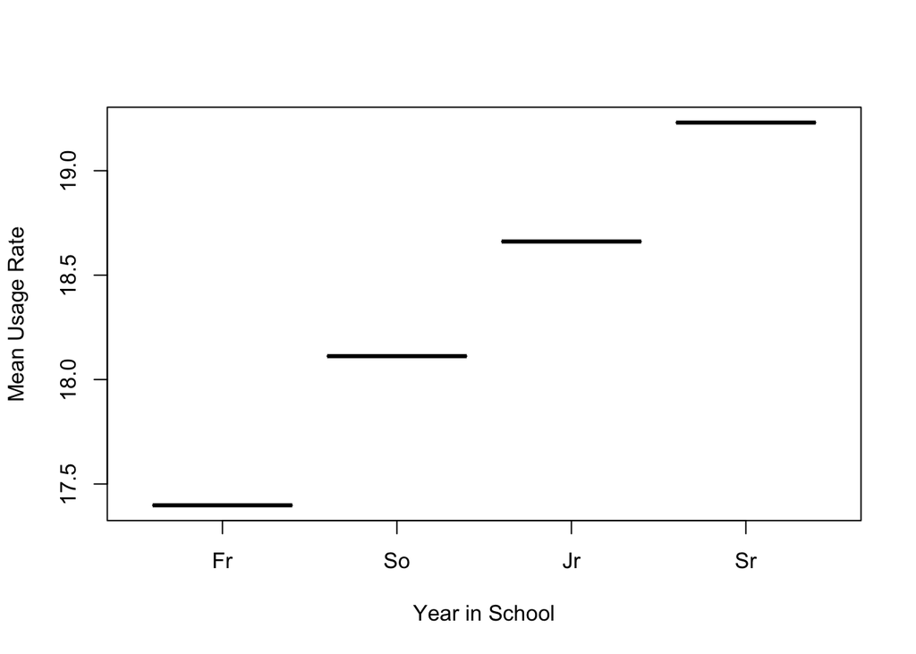

```r
four_year_players <- b_dat %>%
  select(pid, player_name, team, yr) %>%
  group_by(pid) %>%
  count(pid) %>%
  filter(n==4) %>%
  inner_join(b_dat, by=c("pid")) %>%
  select(pid, player_name, team, yr)
#these are players that appear in the data set four times ^

four_year_players <- four_year_players %>%
  group_by(pid, team) %>%
  count(pid, team) %>%
  filter(n==4) %>%
  inner_join(b_dat, by=c("pid", "team")) %>%
  select(pid, player_name, team, yr)
#these are players that played all four years with the same team ^

four_year_players <- four_year_players %>%
  group_by(pid, yr) %>%
  count(pid, yr) %>%
  pivot_wider(names_from = "yr", values_from = "n") %>%
  filter(Fr == 1, So == 1, Jr == 1, Sr == 1) %>%
  select(pid)
#these are players whose four years are traditionally labeled as freshman through senior

four_year_usg <- four_year_players %>%
  inner_join(b_dat, by=c("pid")) %>%
  select(pid, player_name, team, yr, usg) %>%
  pivot_wider(names_from = "yr", values_from = "usg") %>%
  ungroup()

#this is a table of every four year player and their usage stats freshman through senior year

means<- four_year_usg %>%
  select(4:7) %>%
  colMeans(na.rm = TRUE)


library(tibble)
means <- means %>% as.data.frame() %>%
  tibble::rownames_to_column("Yr") %>%
  rename("usg" = 2)
#this code converts the named list into a data frame with the average usg rates

#On average, four-year college players should expect their usage rate to grow from 17.40 freshman year to 19.23 senior year.

#Plotting usg data

x <- factor(means$Yr, levels = c("Fr", "So", "Jr", "Sr"))
y <- means$usg

plot(x, y, xlab="Year in School", ylab="Mean Usage Rate")
```

```r
#Running significance test for usg data
fr_usg <- four_year_usg$Fr
so_usg <- four_year_usg$So
jr_usg <- four_year_usg$Jr
sr_usg <- four_year_usg$Sr

t.test(sr_usg, fr_usg, alternative = "two.sided", var.equal = FALSE)
```

```
##
##  Welch Two Sample t-test
##
## data:  sr_usg and fr_usg
## t = 15.084, df = 8450.3, p-value < 2.2e-16
## alternative hypothesis: true difference in means is not equal to 0
## 95 percent confidence interval:
##  1.594234 2.070499
## sample estimates:
## mean of x mean of y
##  19.23052  17.39815
```

```r
t.test(so_usg, fr_usg, alternative = "two.sided", var.equal = FALSE)
```

```
##
##  Welch Two Sample t-test
##
## data:  so_usg and fr_usg
## t = 6.2621, df = 8548.8, p-value = 3.981e-10
## alternative hypothesis: true difference in means is not equal to 0
## 95 percent confidence interval:
##  0.4905005 0.9375163
## sample estimates:
## mean of x mean of y
##  18.11216  17.39815
```

```r
t.test(jr_usg, so_usg, alternative = "two.sided", var.equal = FALSE)
```

```
##
##  Welch Two Sample t-test
##
## data:  jr_usg and so_usg
## t = 4.6745, df = 8510.4, p-value = 2.992e-06
## alternative hypothesis: true difference in means is not equal to 0
## 95 percent confidence interval:
##  0.3187059 0.7790490
## sample estimates:
## mean of x mean of y
##  18.66104  18.11216
```

```r
#These two-sided difference of means tests show that there is a significant difference between the mean usg rates of freshmen and senior players (test 1). There #is also a significant difference between freshmen and sophomores (test 2) and sophomores and juniors (test 3).
```

On average, four-year college players should expect their usage rate to grow from 17.40 freshman year to 19.23 senior year.

### Which player scored the most points in their college career out of all players from 2009-2021, and were they drafted in the first round?

```r
b_dat=mutate(b_dat,totalpts=pts*GP)
b_dat=mutate(b_dat, totalptsrnd=round(totalpts,0))
Boypointstotal= b_dat %>%
  group_by(player_name, team, pick) %>%
  summarise(TOTALPTS =sum(totalptsrnd))
kable(head(arrange(Boypointstotal, desc(TOTALPTS))))
```

| player_name | team | pick | TOTALPTS |
| --- | --- | --- | --- |
| Doug McDermott | Creighton | 11 | 3150 |
| Chris Clemons | Campbell | NA | 2950 |
| Mike Daum | South Dakota St. | NA | 2862 |
| Markus Howard | Marquette | NA | 2759 |
| Tyler Haws | BYU | NA | 2649 |
| Jon Elmore | Marshall | NA | 2591 |

Doug McDermott was the player with the most career points of any player from 2009-2021, and he was drafted in the first round of the 2014 NBA Draft.

### From 2009 through 2021, how have the median points per game from freshman to senior year changed?

```r
library(ggplot2)

b_dat2 <- b_dat[c("pts", "yr", "year")]
#head(b_dat2)

b_dat3 <- filter(b_dat2, yr == "Fr")
#head(b_dat3)

bdat6<- group_by(b_dat3, year)
head(bdat6)
```

```
## # A tibble: 6 × 3
## # Groups:   year [1]
##     pts yr     year
##   <dbl> <chr> <dbl>
## 1 9.65  Fr     2009
## 2 2     Fr     2009
## 3 0.5   Fr     2009
## 4 7.75  Fr     2009
## 5 0.571 Fr     2009
## 6 0     Fr     2009
```

```r
Frmean <- bdat6%>%
  summarise(Median_Years = median(pts, na.rm = TRUE))

head(Frmean, 13)
```

```
## # A tibble: 13 × 2
##     year Median_Years
##    <dbl>        <dbl>
##  1  2009         2.16
##  2  2010         2.37
##  3  2011         2.33
##  4  2012         2.33
##  5  2013         2.40
##  6  2014         2.36
##  7  2015         2.6
##  8  2016         2.45
##  9  2017         2.73
## 10  2018         3
## 11  2019         2.82
## 12  2020         2.68
## 13  2021         2.29
```

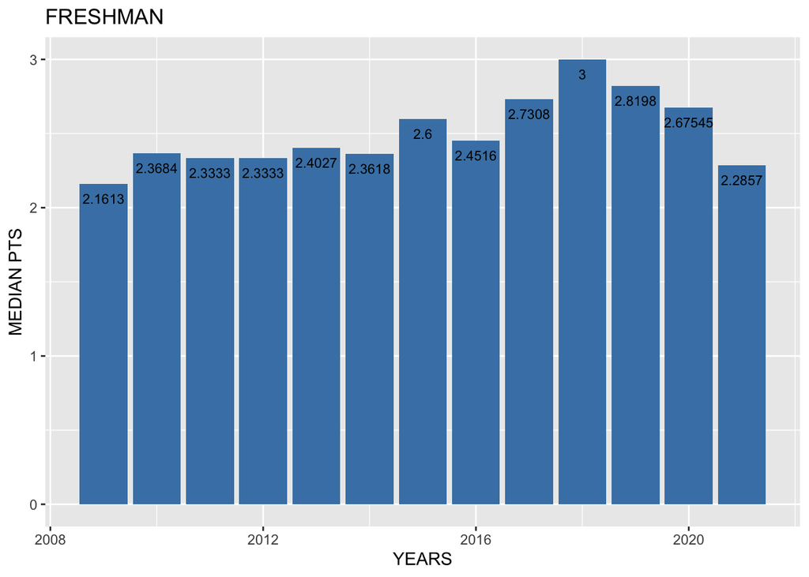

```r
ggplot(data=Frmean, aes(x= year, y= Median_Years)) +
  geom_bar(stat = "identity", fill = "steelblue")+
   geom_text(aes(label = Median_Years), vjust = 2, size = 3)+
  labs(title="FRESHMAN",
        x ="YEARS", y = "MEDIAN PTS")
```

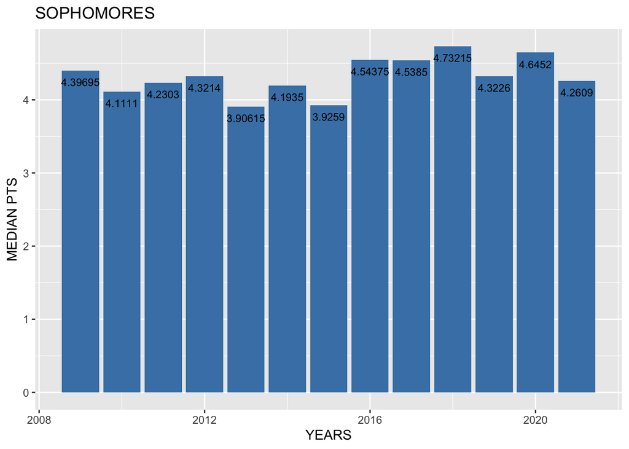

```r
# Choosing to directly analyze freshman median points in order to see their direct impact on the game in regards to points and whether or not
# over a span of 13 yrs if we have seen a greater presence of freshman in college basketball.


#Sophomores
b2 <- b_dat[c("pts", "yr", "year")]
#head(b_dat2)

b3 <- filter(b2, yr == "So")
#head(b_dat3)

b4<- group_by(b3, year)


Somean <- b4%>%
  summarise(Median_Years = median(pts, na.rm = TRUE))


ggplot(data=Somean, aes(x= year, y= Median_Years)) +
  geom_bar(stat = "identity", fill = "steelblue")+
   geom_text(aes(label = Median_Years), vjust = 2, size = 3)+
  labs(title="SOPHOMORES",
        x ="YEARS", y = "MEDIAN PTS")
```

```r
# Juniors
b5 <- b_dat[c("pts", "yr", "year")]
#head(b_dat2)

b6 <- filter(b5, yr == "Jr")
#head(b_dat3)

b7<- group_by(b6, year)
head(bdat6)
```

```
## # A tibble: 6 × 3
## # Groups:   year [1]
##     pts yr     year
##   <dbl> <chr> <dbl>
## 1 9.65  Fr     2009
## 2 2     Fr     2009
## 3 0.5   Fr     2009
## 4 7.75  Fr     2009
## 5 0.571 Fr     2009
## 6 0     Fr     2009
```

```r
Jrmean <- b7%>%
  summarise(Median_Years = median(pts, na.rm = TRUE))

head(Jrmean, 13)
```

```
## # A tibble: 13 × 2
##     year Median_Years
##    <dbl>        <dbl>
##  1  2009         5.53
##  2  2010         5.71
##  3  2011         5.38
##  4  2012         5.85
##  5  2013         5.6
##  6  2014         5.57
##  7  2015         5.81
##  8  2016         5.68
##  9  2017         5.67
## 10  2018         5.64
## 11  2019         6.03
## 12  2020         6
## 13  2021         6
```

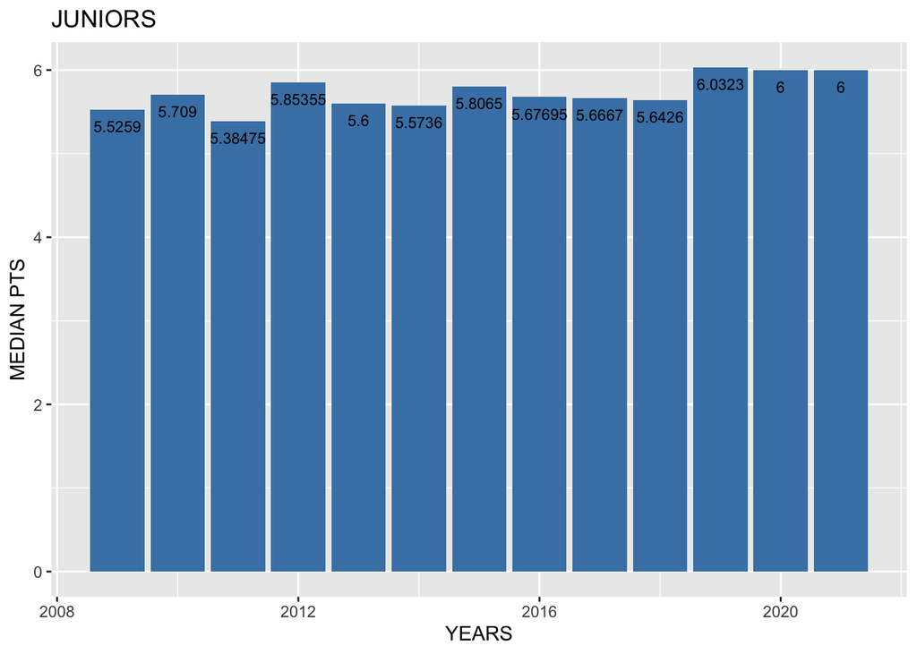

```r
ggplot(data=Jrmean, aes(x= year, y= Median_Years)) +
  geom_bar(stat = "identity", fill = "steelblue")+
   geom_text(aes(label = Median_Years), vjust = 2, size = 3)+
  labs(title="JUNIORS",
        x ="YEARS", y = "MEDIAN PTS")
```

```r
#Seniors
b8 <- b_dat[c("pts", "yr", "year")]
#head(b_dat2)

b9 <- filter(b8, yr == "Sr")
#head(b_dat3)

b9<- group_by(b9, year)
head(bdat6)
```

```
## # A tibble: 6 × 3
## # Groups:   year [1]
##     pts yr     year
##   <dbl> <chr> <dbl>
## 1 9.65  Fr     2009
## 2 2     Fr     2009
## 3 0.5   Fr     2009
## 4 7.75  Fr     2009
## 5 0.571 Fr     2009
## 6 0     Fr     2009
```

```r
Srmean <- b9%>%
  summarise(Median_Years = median(pts, na.rm = TRUE))

head(Srmean, 13)
```

```
## # A tibble: 13 × 2
##     year Median_Years
##    <dbl>        <dbl>
##  1  2009         6.73
##  2  2010         6.75
##  3  2011         7.41
##  4  2012         7.06
##  5  2013         7.03
##  6  2014         7.4
##  7  2015         7
##  8  2016         7.53
##  9  2017         7.53
## 10  2018         7
## 11  2019         7.48
## 12  2020         7.75
## 13  2021         7.5
```

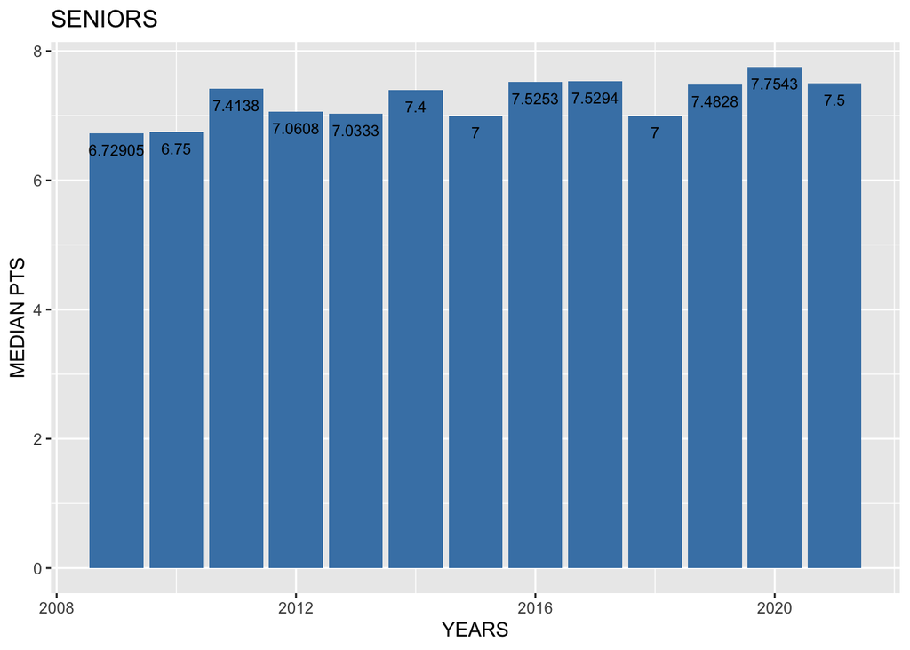

```r
ggplot(data=Srmean, aes(x= year, y= Median_Years)) +
  geom_bar(stat = "identity", fill = "steelblue")+
   geom_text(aes(label = Median_Years), vjust = 2, size = 3)+
  labs(title="SENIORS",
        x ="YEARS", y = "MEDIAN PTS")
```

```r
# from this data we are able to see that as the player progresses from year to year they their impact on this game in regards to points increases.
```